# Risk Factor Analysis

## Outcome Variable

**Outcome Variable:** whz

## Predictor Variables

**Intervention Variable:** vagbrth

**Adjustment Set:**

- arm
- sex
- W_mage
- meducyrs
- feducyrs
- W_mhtcm
- single
- brthmon
- W_parity
- delta_W_mage
- delta_meducyrs
- delta_feducyrs
- delta_W_mhtcm
- delta_single
- delta_brthmon
- delta_W_parity

## Stratifying Variables

The analysis was stratified on these variable(s):

- agecat
- studyid
- country

## Data Summary

| agecat | studyid | country | vagbrth | n_cell | n |
| --- | --- | --- | --- | --- | --- |
| Birth | ki1000108-CMC-V-BCS-2002 | INDIA | 0 | 10 | 88 |
| Birth | ki1000108-CMC-V-BCS-2002 | INDIA | 1 | 78 | 88 |
| Birth | ki1000108-IRC | INDIA | 0 | 66 | 343 |
| Birth | ki1000108-IRC | INDIA | 1 | 277 | 343 |
| Birth | ki1017093c-NIH-Crypto | BANGLADESH | 0 | 1 | 17 |
| Birth | ki1017093c-NIH-Crypto | BANGLADESH | 1 | 16 | 17 |
| Birth | ki1119695-PROBIT | BELARUS | 0 | 1593 | 13824 |
| Birth | ki1119695-PROBIT | BELARUS | 1 | 12231 | 13824 |
| Birth | ki1126311-ZVITAMBO | ZIMBABWE | 0 | 1099 | 12813 |
| Birth | ki1126311-ZVITAMBO | ZIMBABWE | 1 | 11714 | 12813 |
| Birth | kiGH5241-JiVitA-3 | BANGLADESH | 0 | 2 | 15689 |
| Birth | kiGH5241-JiVitA-3 | BANGLADESH | 1 | 15687 | 15689 |
| Birth | kiGH5241-JiVitA-4 | BANGLADESH | 0 | 1 | 683 |
| Birth | kiGH5241-JiVitA-4 | BANGLADESH | 1 | 682 | 683 |
| 6 months | ki1000108-CMC-V-BCS-2002 | INDIA | 0 | 25 | 368 |
| 6 months | ki1000108-CMC-V-BCS-2002 | INDIA | 1 | 343 | 368 |
| 6 months | ki1000108-IRC | INDIA | 0 | 68 | 408 |
| 6 months | ki1000108-IRC | INDIA | 1 | 340 | 408 |
| 6 months | ki1017093b-PROVIDE | BANGLADESH | 0 | 134 | 582 |
| 6 months | ki1017093b-PROVIDE | BANGLADESH | 1 | 448 | 582 |
| 6 months | ki1017093c-NIH-Crypto | BANGLADESH | 0 | 187 | 457 |
| 6 months | ki1017093c-NIH-Crypto | BANGLADESH | 1 | 270 | 457 |
| 6 months | ki1066203-TanzaniaChild2 | TANZANIA, UNITED REPUBLIC OF | 0 | 189 | 2004 |
| 6 months | ki1066203-TanzaniaChild2 | TANZANIA, UNITED REPUBLIC OF | 1 | 1815 | 2004 |
| 6 months | ki1119695-PROBIT | BELARUS | 0 | 1798 | 15757 |
| 6 months | ki1119695-PROBIT | BELARUS | 1 | 13959 | 15757 |
| 6 months | ki1126311-ZVITAMBO | ZIMBABWE | 0 | 706 | 8197 |
| 6 months | ki1126311-ZVITAMBO | ZIMBABWE | 1 | 7491 | 8197 |
| 6 months | kiGH5241-JiVitA-3 | BANGLADESH | 0 | 1075 | 16705 |
| 6 months | kiGH5241-JiVitA-3 | BANGLADESH | 1 | 15630 | 16705 |
| 6 months | kiGH5241-JiVitA-4 | BANGLADESH | 0 | 337 | 4056 |
| 6 months | kiGH5241-JiVitA-4 | BANGLADESH | 1 | 3719 | 4056 |
| 24 months | ki1000108-CMC-V-BCS-2002 | INDIA | 0 | 25 | 372 |
| 24 months | ki1000108-CMC-V-BCS-2002 | INDIA | 1 | 347 | 372 |
| 24 months | ki1000108-IRC | INDIA | 0 | 69 | 409 |
| 24 months | ki1000108-IRC | INDIA | 1 | 340 | 409 |
| 24 months | ki1017093b-PROVIDE | BANGLADESH | 0 | 137 | 578 |
| 24 months | ki1017093b-PROVIDE | BANGLADESH | 1 | 441 | 578 |
| 24 months | ki1017093c-NIH-Crypto | BANGLADESH | 0 | 99 | 260 |
| 24 months | ki1017093c-NIH-Crypto | BANGLADESH | 1 | 161 | 260 |
| 24 months | ki1066203-TanzaniaChild2 | TANZANIA, UNITED REPUBLIC OF | 0 | 2 | 6 |
| 24 months | ki1066203-TanzaniaChild2 | TANZANIA, UNITED REPUBLIC OF | 1 | 4 | 6 |
| 24 months | ki1119695-PROBIT | BELARUS | 0 | 463 | 3971 |
| 24 months | ki1119695-PROBIT | BELARUS | 1 | 3508 | 3971 |
| 24 months | ki1126311-ZVITAMBO | ZIMBABWE | 0 | 28 | 417 |
| 24 months | ki1126311-ZVITAMBO | ZIMBABWE | 1 | 389 | 417 |
| 24 months | kiGH5241-JiVitA-3 | BANGLADESH | 0 | 475 | 8555 |
| 24 months | kiGH5241-JiVitA-3 | BANGLADESH | 1 | 8080 | 8555 |
| 24 months | kiGH5241-JiVitA-4 | BANGLADESH | 0 | 323 | 4008 |
| 24 months | kiGH5241-JiVitA-4 | BANGLADESH | 1 | 3685 | 4008 |

The following strata were considered:

- agecat: 24 months, studyid: ki1000108-CMC-V-BCS-2002, country: INDIA
- agecat: 24 months, studyid: ki1000108-IRC, country: INDIA
- agecat: 24 months, studyid: ki1017093b-PROVIDE, country: BANGLADESH
- agecat: 24 months, studyid: ki1017093c-NIH-Crypto, country: BANGLADESH
- agecat: 24 months, studyid: ki1066203-TanzaniaChild2, country: TANZANIA, UNITED REPUBLIC OF
- agecat: 24 months, studyid: ki1119695-PROBIT, country: BELARUS
- agecat: 24 months, studyid: ki1126311-ZVITAMBO, country: ZIMBABWE
- agecat: 24 months, studyid: kiGH5241-JiVitA-3, country: BANGLADESH
- agecat: 24 months, studyid: kiGH5241-JiVitA-4, country: BANGLADESH
- agecat: 6 months, studyid: ki1000108-CMC-V-BCS-2002, country: INDIA
- agecat: 6 months, studyid: ki1000108-IRC, country: INDIA
- agecat: 6 months, studyid: ki1017093b-PROVIDE, country: BANGLADESH
- agecat: 6 months, studyid: ki1017093c-NIH-Crypto, country: BANGLADESH
- agecat: 6 months, studyid: ki1066203-TanzaniaChild2, country: TANZANIA, UNITED REPUBLIC OF
- agecat: 6 months, studyid: ki1119695-PROBIT, country: BELARUS
- agecat: 6 months, studyid: ki1126311-ZVITAMBO, country: ZIMBABWE
- agecat: 6 months, studyid: kiGH5241-JiVitA-3, country: BANGLADESH
- agecat: 6 months, studyid: kiGH5241-JiVitA-4, country: BANGLADESH
- agecat: Birth, studyid: ki1000108-CMC-V-BCS-2002, country: INDIA
- agecat: Birth, studyid: ki1000108-IRC, country: INDIA
- agecat: Birth, studyid: ki1017093c-NIH-Crypto, country: BANGLADESH
- agecat: Birth, studyid: ki1119695-PROBIT, country: BELARUS
- agecat: Birth, studyid: ki1126311-ZVITAMBO, country: ZIMBABWE
- agecat: Birth, studyid: kiGH5241-JiVitA-3, country: BANGLADESH
- agecat: Birth, studyid: kiGH5241-JiVitA-4, country: BANGLADESH

### Dropped Strata

Some strata were dropped due to rare outcomes:

- agecat: Birth, studyid: ki1017093c-NIH-Crypto, country: BANGLADESH
- agecat: Birth, studyid: kiGH5241-JiVitA-3, country: BANGLADESH
- agecat: Birth, studyid: kiGH5241-JiVitA-4, country: BANGLADESH
- agecat: 24 months, studyid: ki1066203-TanzaniaChild2, country: TANZANIA, UNITED REPUBLIC OF

## Methods Detail

We’re interested in the causal parameters $E[Y_a]$ for all values of $a \in \mathcal{A}$. These parameters represent the mean outcome if, possibly contrary to fact, we intervened to set all units to have $A=a$. Under the randomization and positivity assumptions, these are identified by the statistical parameters $\psi_a=E_W[E_{Y|A,W}(Y|A=a,W)]$. In addition, we’re interested in the mean of $Y$, $E[Y]$ under no intervention (the observed mean). We will estimate these parameters by using SuperLearner to fit the relevant likelihood factors – $E_{Y|A,W}(Y|A=a,W)$ and $p(A=a|W)$, and then updating our likelihood fit using a joint TMLE.

For unadjusted analyses ($W=\{\}$), initial likelihoods were estimated using Lrnr_glm to estimate the simple $E(Y|A)$ and Lrnr_mean to estimate $p(A)$. For adjusted analyses, a small library containing Lrnr_glmnet, Lrnr_xgboost, and Lrnr_mean was used.

Having estimated these parameters, we will then use the delta method to estimate relative risks and attributable risks relative to a prespecified baseline level of $A$.

# Results Detail

## Results Plots

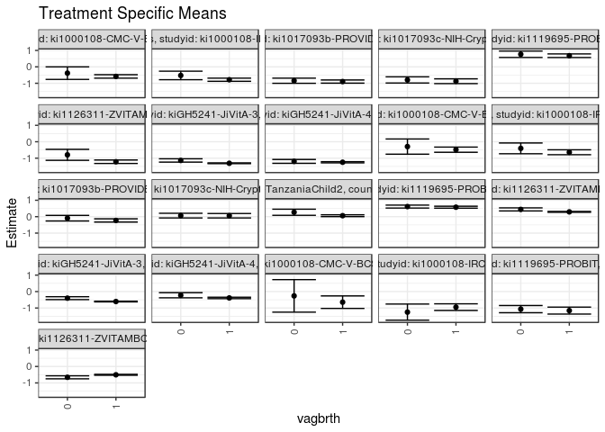

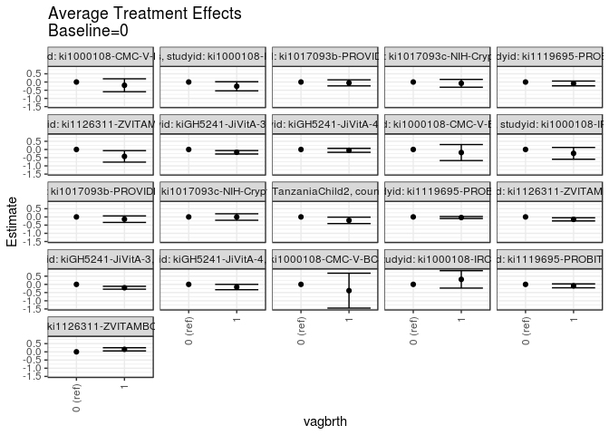

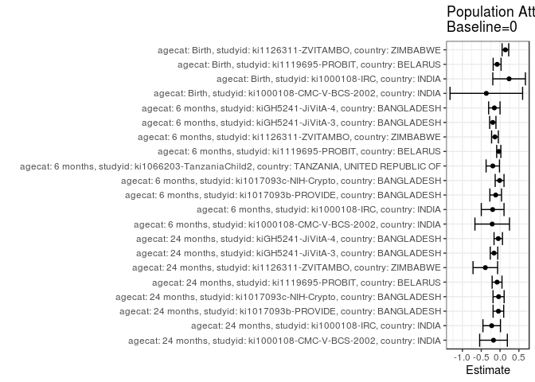

## Results Table

### Parameter: TSM

| agecat | studyid | country | intervention_level | baseline_level | estimate | ci_lower | ci_upper |
| --- | --- | --- | --- | --- | --- | --- | --- |
| Birth | ki1000108-CMC-V-BCS-2002 | INDIA | 0 | NA | -0.2626165 | -1.2529913 | 0.7277584 |
| Birth | ki1000108-CMC-V-BCS-2002 | INDIA | 1 | NA | -0.6450573 | -1.0254444 | -0.2646701 |
| Birth | ki1000108-IRC | INDIA | 0 | NA | -1.2506864 | -1.7417373 | -0.7596355 |
| Birth | ki1000108-IRC | INDIA | 1 | NA | -0.9468147 | -1.1484150 | -0.7452145 |
| Birth | ki1119695-PROBIT | BELARUS | 0 | NA | -1.0680511 | -1.2872019 | -0.8489002 |
| Birth | ki1119695-PROBIT | BELARUS | 1 | NA | -1.1574652 | -1.3692245 | -0.9457059 |
| Birth | ki1126311-ZVITAMBO | ZIMBABWE | 0 | NA | -0.6581159 | -0.7496448 | -0.5665871 |
| Birth | ki1126311-ZVITAMBO | ZIMBABWE | 1 | NA | -0.5057570 | -0.5329055 | -0.4786085 |
| 6 months | ki1000108-CMC-V-BCS-2002 | INDIA | 0 | NA | -0.2939915 | -0.7572208 | 0.1692378 |
| 6 months | ki1000108-CMC-V-BCS-2002 | INDIA | 1 | NA | -0.4822910 | -0.6402395 | -0.3243425 |
| 6 months | ki1000108-IRC | INDIA | 0 | NA | -0.4024080 | -0.7300947 | -0.0747213 |
| 6 months | ki1000108-IRC | INDIA | 1 | NA | -0.6386782 | -0.7875261 | -0.4898304 |
| 6 months | ki1017093b-PROVIDE | BANGLADESH | 0 | NA | -0.0922232 | -0.2627818 | 0.0783354 |
| 6 months | ki1017093b-PROVIDE | BANGLADESH | 1 | NA | -0.2298498 | -0.3286100 | -0.1310895 |
| 6 months | ki1017093c-NIH-Crypto | BANGLADESH | 0 | NA | 0.0636757 | -0.0785122 | 0.2058636 |
| 6 months | ki1017093c-NIH-Crypto | BANGLADESH | 1 | NA | 0.0576626 | -0.0772196 | 0.1925447 |
| 6 months | ki1066203-TanzaniaChild2 | TANZANIA, UNITED REPUBLIC OF | 0 | NA | 0.2696396 | 0.0834177 | 0.4558616 |
| 6 months | ki1066203-TanzaniaChild2 | TANZANIA, UNITED REPUBLIC OF | 1 | NA | 0.0593919 | 0.0040126 | 0.1147713 |
| 6 months | ki1119695-PROBIT | BELARUS | 0 | NA | 0.6131107 | 0.5242950 | 0.7019264 |
| 6 months | ki1119695-PROBIT | BELARUS | 1 | NA | 0.5762036 | 0.5165635 | 0.6358437 |
| 6 months | ki1126311-ZVITAMBO | ZIMBABWE | 0 | NA | 0.4411073 | 0.3480356 | 0.5341789 |
| 6 months | ki1126311-ZVITAMBO | ZIMBABWE | 1 | NA | 0.2923817 | 0.2649798 | 0.3197836 |
| 6 months | kiGH5241-JiVitA-3 | BANGLADESH | 0 | NA | -0.4004197 | -0.4881517 | -0.3126876 |
| 6 months | kiGH5241-JiVitA-3 | BANGLADESH | 1 | NA | -0.6062049 | -0.6258996 | -0.5865102 |
| 6 months | kiGH5241-JiVitA-4 | BANGLADESH | 0 | NA | -0.2239232 | -0.3808679 | -0.0669786 |
| 6 months | kiGH5241-JiVitA-4 | BANGLADESH | 1 | NA | -0.3869260 | -0.4316702 | -0.3421819 |
| 24 months | ki1000108-CMC-V-BCS-2002 | INDIA | 0 | NA | -0.3829521 | -0.7634932 | -0.0024111 |
| 24 months | ki1000108-CMC-V-BCS-2002 | INDIA | 1 | NA | -0.5824671 | -0.6870465 | -0.4778876 |
| 24 months | ki1000108-IRC | INDIA | 0 | NA | -0.5239459 | -0.7827076 | -0.2651841 |
| 24 months | ki1000108-IRC | INDIA | 1 | NA | -0.7841442 | -0.8801913 | -0.6880970 |
| 24 months | ki1017093b-PROVIDE | BANGLADESH | 0 | NA | -0.8438041 | -1.0008466 | -0.6867617 |
| 24 months | ki1017093b-PROVIDE | BANGLADESH | 1 | NA | -0.8959405 | -0.9929638 | -0.7989172 |
| 24 months | ki1017093c-NIH-Crypto | BANGLADESH | 0 | NA | -0.7951680 | -0.9830909 | -0.6072452 |
| 24 months | ki1017093c-NIH-Crypto | BANGLADESH | 1 | NA | -0.8742987 | -1.0190724 | -0.7295250 |
| 24 months | ki1119695-PROBIT | BELARUS | 0 | NA | 0.7656227 | 0.5723625 | 0.9588829 |
| 24 months | ki1119695-PROBIT | BELARUS | 1 | NA | 0.6780635 | 0.5677441 | 0.7883830 |
| 24 months | ki1126311-ZVITAMBO | ZIMBABWE | 0 | NA | -0.7957232 | -1.1294682 | -0.4619782 |
| 24 months | ki1126311-ZVITAMBO | ZIMBABWE | 1 | NA | -1.2171464 | -1.3221799 | -1.1121128 |
| 24 months | kiGH5241-JiVitA-3 | BANGLADESH | 0 | NA | -1.1376174 | -1.2396464 | -1.0355884 |
| 24 months | kiGH5241-JiVitA-3 | BANGLADESH | 1 | NA | -1.3092979 | -1.3332001 | -1.2853958 |
| 24 months | kiGH5241-JiVitA-4 | BANGLADESH | 0 | NA | -1.1953490 | -1.3120519 | -1.0786461 |
| 24 months | kiGH5241-JiVitA-4 | BANGLADESH | 1 | NA | -1.2473542 | -1.2828254 | -1.2118829 |

### Parameter: E(Y)

| agecat | studyid | country | intervention_level | baseline_level | estimate | ci_lower | ci_upper |
| --- | --- | --- | --- | --- | --- | --- | --- |
| Birth | ki1000108-CMC-V-BCS-2002 | INDIA | NA | NA | -0.6275000 | -0.9746292 | -0.2803708 |
| Birth | ki1000108-IRC | INDIA | NA | NA | -1.0105831 | -1.1973019 | -0.8238643 |
| Birth | ki1119695-PROBIT | BELARUS | NA | NA | -1.1463469 | -1.3562674 | -0.9364264 |
| Birth | ki1126311-ZVITAMBO | ZIMBABWE | NA | NA | -0.5165387 | -0.5425056 | -0.4905717 |
| 6 months | ki1000108-CMC-V-BCS-2002 | INDIA | NA | NA | -0.5026766 | -0.6536848 | -0.3516685 |
| 6 months | ki1000108-IRC | INDIA | NA | NA | -0.5989297 | -0.7344491 | -0.4634104 |
| 6 months | ki1017093b-PROVIDE | BANGLADESH | NA | NA | -0.2083706 | -0.2927992 | -0.1239419 |
| 6 months | ki1017093c-NIH-Crypto | BANGLADESH | NA | NA | 0.0515536 | -0.0469240 | 0.1500313 |
| 6 months | ki1066203-TanzaniaChild2 | TANZANIA, UNITED REPUBLIC OF | NA | NA | 0.0769382 | 0.0241090 | 0.1297674 |
| 6 months | ki1119695-PROBIT | BELARUS | NA | NA | 0.5789633 | 0.5190130 | 0.6389137 |
| 6 months | ki1126311-ZVITAMBO | ZIMBABWE | NA | NA | 0.3058247 | 0.2796439 | 0.3320055 |
| 6 months | kiGH5241-JiVitA-3 | BANGLADESH | NA | NA | -0.5935070 | -0.6130727 | -0.5739413 |
| 6 months | kiGH5241-JiVitA-4 | BANGLADESH | NA | NA | -0.3758037 | -0.4184544 | -0.3331531 |
| 24 months | ki1000108-CMC-V-BCS-2002 | INDIA | NA | NA | -0.5571505 | -0.6585247 | -0.4557763 |
| 24 months | ki1000108-IRC | INDIA | NA | NA | -0.7458150 | -0.8368180 | -0.6548120 |
| 24 months | ki1017093b-PROVIDE | BANGLADESH | NA | NA | -0.8879412 | -0.9708680 | -0.8050144 |
| 24 months | ki1017093c-NIH-Crypto | BANGLADESH | NA | NA | -0.8343077 | -0.9482310 | -0.7203844 |
| 24 months | ki1119695-PROBIT | BELARUS | NA | NA | 0.6863435 | 0.5745700 | 0.7981170 |
| 24 months | ki1126311-ZVITAMBO | ZIMBABWE | NA | NA | -1.1870743 | -1.2881393 | -1.0860094 |
| 24 months | kiGH5241-JiVitA-3 | BANGLADESH | NA | NA | -1.2983928 | -1.3216893 | -1.2750962 |
| 24 months | kiGH5241-JiVitA-4 | BANGLADESH | NA | NA | -1.2433658 | -1.2774681 | -1.2092634 |

### Parameter: ATE

| agecat | studyid | country | intervention_level | baseline_level | estimate | ci_lower | ci_upper |
| --- | --- | --- | --- | --- | --- | --- | --- |
| Birth | ki1000108-CMC-V-BCS-2002 | INDIA | 0 | 0 | 0.0000000 | 0.0000000 | 0.0000000 |
| Birth | ki1000108-CMC-V-BCS-2002 | INDIA | 1 | 0 | -0.3824408 | -1.4464324 | 0.6815508 |
| Birth | ki1000108-IRC | INDIA | 0 | 0 | 0.0000000 | 0.0000000 | 0.0000000 |
| Birth | ki1000108-IRC | INDIA | 1 | 0 | 0.3038717 | -0.2279942 | 0.8357376 |
| Birth | ki1119695-PROBIT | BELARUS | 0 | 0 | 0.0000000 | 0.0000000 | 0.0000000 |
| Birth | ki1119695-PROBIT | BELARUS | 1 | 0 | -0.0894142 | -0.2074769 | 0.0286485 |
| Birth | ki1126311-ZVITAMBO | ZIMBABWE | 0 | 0 | 0.0000000 | 0.0000000 | 0.0000000 |
| Birth | ki1126311-ZVITAMBO | ZIMBABWE | 1 | 0 | 0.1523589 | 0.0569233 | 0.2477945 |
| 6 months | ki1000108-CMC-V-BCS-2002 | INDIA | 0 | 0 | 0.0000000 | 0.0000000 | 0.0000000 |
| 6 months | ki1000108-CMC-V-BCS-2002 | INDIA | 1 | 0 | -0.1882995 | -0.6769279 | 0.3003289 |
| 6 months | ki1000108-IRC | INDIA | 0 | 0 | 0.0000000 | 0.0000000 | 0.0000000 |
| 6 months | ki1000108-IRC | INDIA | 1 | 0 | -0.2362702 | -0.5964357 | 0.1238953 |
| 6 months | ki1017093b-PROVIDE | BANGLADESH | 0 | 0 | 0.0000000 | 0.0000000 | 0.0000000 |
| 6 months | ki1017093b-PROVIDE | BANGLADESH | 1 | 0 | -0.1376266 | -0.3365787 | 0.0613254 |
| 6 months | ki1017093c-NIH-Crypto | BANGLADESH | 0 | 0 | 0.0000000 | 0.0000000 | 0.0000000 |
| 6 months | ki1017093c-NIH-Crypto | BANGLADESH | 1 | 0 | -0.0060131 | -0.2027956 | 0.1907694 |
| 6 months | ki1066203-TanzaniaChild2 | TANZANIA, UNITED REPUBLIC OF | 0 | 0 | 0.0000000 | 0.0000000 | 0.0000000 |
| 6 months | ki1066203-TanzaniaChild2 | TANZANIA, UNITED REPUBLIC OF | 1 | 0 | -0.2102477 | -0.4046064 | -0.0158890 |
| 6 months | ki1119695-PROBIT | BELARUS | 0 | 0 | 0.0000000 | 0.0000000 | 0.0000000 |
| 6 months | ki1119695-PROBIT | BELARUS | 1 | 0 | -0.0369071 | -0.0983075 | 0.0244933 |
| 6 months | ki1126311-ZVITAMBO | ZIMBABWE | 0 | 0 | 0.0000000 | 0.0000000 | 0.0000000 |
| 6 months | ki1126311-ZVITAMBO | ZIMBABWE | 1 | 0 | -0.1487256 | -0.2457708 | -0.0516803 |
| 6 months | kiGH5241-JiVitA-3 | BANGLADESH | 0 | 0 | 0.0000000 | 0.0000000 | 0.0000000 |
| 6 months | kiGH5241-JiVitA-3 | BANGLADESH | 1 | 0 | -0.2057852 | -0.2935568 | -0.1180137 |
| 6 months | kiGH5241-JiVitA-4 | BANGLADESH | 0 | 0 | 0.0000000 | 0.0000000 | 0.0000000 |
| 6 months | kiGH5241-JiVitA-4 | BANGLADESH | 1 | 0 | -0.1630028 | -0.3271894 | 0.0011838 |
| 24 months | ki1000108-CMC-V-BCS-2002 | INDIA | 0 | 0 | 0.0000000 | 0.0000000 | 0.0000000 |
| 24 months | ki1000108-CMC-V-BCS-2002 | INDIA | 1 | 0 | -0.1995149 | -0.5937877 | 0.1947578 |
| 24 months | ki1000108-IRC | INDIA | 0 | 0 | 0.0000000 | 0.0000000 | 0.0000000 |
| 24 months | ki1000108-IRC | INDIA | 1 | 0 | -0.2601983 | -0.5365037 | 0.0161071 |
| 24 months | ki1017093b-PROVIDE | BANGLADESH | 0 | 0 | 0.0000000 | 0.0000000 | 0.0000000 |
| 24 months | ki1017093b-PROVIDE | BANGLADESH | 1 | 0 | -0.0521363 | -0.2362314 | 0.1319587 |
| 24 months | ki1017093c-NIH-Crypto | BANGLADESH | 0 | 0 | 0.0000000 | 0.0000000 | 0.0000000 |
| 24 months | ki1017093c-NIH-Crypto | BANGLADESH | 1 | 0 | -0.0791307 | -0.3169374 | 0.1586761 |
| 24 months | ki1119695-PROBIT | BELARUS | 0 | 0 | 0.0000000 | 0.0000000 | 0.0000000 |
| 24 months | ki1119695-PROBIT | BELARUS | 1 | 0 | -0.0875592 | -0.2334545 | 0.0583361 |
| 24 months | ki1126311-ZVITAMBO | ZIMBABWE | 0 | 0 | 0.0000000 | 0.0000000 | 0.0000000 |
| 24 months | ki1126311-ZVITAMBO | ZIMBABWE | 1 | 0 | -0.4214231 | -0.7714651 | -0.0713812 |
| 24 months | kiGH5241-JiVitA-3 | BANGLADESH | 0 | 0 | 0.0000000 | 0.0000000 | 0.0000000 |
| 24 months | kiGH5241-JiVitA-3 | BANGLADESH | 1 | 0 | -0.1716805 | -0.2759925 | -0.0673685 |
| 24 months | kiGH5241-JiVitA-4 | BANGLADESH | 0 | 0 | 0.0000000 | 0.0000000 | 0.0000000 |
| 24 months | kiGH5241-JiVitA-4 | BANGLADESH | 1 | 0 | -0.0520052 | -0.1735607 | 0.0695504 |

### Parameter: PAR

| agecat | studyid | country | intervention_level | baseline_level | estimate | ci_lower | ci_upper |
| --- | --- | --- | --- | --- | --- | --- | --- |
| Birth | ki1000108-CMC-V-BCS-2002 | INDIA | 0 | NA | -0.3648835 | -1.3286317 | 0.5988647 |
| Birth | ki1000108-IRC | INDIA | 0 | NA | 0.2401033 | -0.1930478 | 0.6732545 |
| Birth | ki1119695-PROBIT | BELARUS | 0 | NA | -0.0782959 | -0.1831949 | 0.0266031 |
| Birth | ki1126311-ZVITAMBO | ZIMBABWE | 0 | NA | 0.1415772 | 0.0538776 | 0.2292769 |
| 6 months | ki1000108-CMC-V-BCS-2002 | INDIA | 0 | NA | -0.2086851 | -0.6674219 | 0.2500516 |
| 6 months | ki1000108-IRC | INDIA | 0 | NA | -0.1965217 | -0.4983368 | 0.1052933 |
| 6 months | ki1017093b-PROVIDE | BANGLADESH | 0 | NA | -0.1161474 | -0.2707333 | 0.0384385 |
| 6 months | ki1017093c-NIH-Crypto | BANGLADESH | 0 | NA | -0.0121221 | -0.1293566 | 0.1051125 |
| 6 months | ki1066203-TanzaniaChild2 | TANZANIA, UNITED REPUBLIC OF | 0 | NA | -0.1927014 | -0.3704591 | -0.0149438 |
| 6 months | ki1119695-PROBIT | BELARUS | 0 | NA | -0.0341474 | -0.0892908 | 0.0209961 |
| 6 months | ki1126311-ZVITAMBO | ZIMBABWE | 0 | NA | -0.1352826 | -0.2244095 | -0.0461556 |
| 6 months | kiGH5241-JiVitA-3 | BANGLADESH | 0 | NA | -0.1930874 | -0.2768125 | -0.1093623 |
| 6 months | kiGH5241-JiVitA-4 | BANGLADESH | 0 | NA | -0.1518805 | -0.3031104 | -0.0006507 |
| 24 months | ki1000108-CMC-V-BCS-2002 | INDIA | 0 | NA | -0.1741984 | -0.5419557 | 0.1935589 |
| 24 months | ki1000108-IRC | INDIA | 0 | NA | -0.2218691 | -0.4544688 | 0.0107306 |
| 24 months | ki1017093b-PROVIDE | BANGLADESH | 0 | NA | -0.0441370 | -0.1851875 | 0.0969134 |
| 24 months | ki1017093c-NIH-Crypto | BANGLADESH | 0 | NA | -0.0391397 | -0.1866690 | 0.1083897 |
| 24 months | ki1119695-PROBIT | BELARUS | 0 | NA | -0.0792792 | -0.2101851 | 0.0516266 |
| 24 months | ki1126311-ZVITAMBO | ZIMBABWE | 0 | NA | -0.3913511 | -0.7177872 | -0.0649151 |
| 24 months | kiGH5241-JiVitA-3 | BANGLADESH | 0 | NA | -0.1607753 | -0.2603228 | -0.0612279 |
| 24 months | kiGH5241-JiVitA-4 | BANGLADESH | 0 | NA | -0.0480168 | -0.1599008 | 0.0638673 |